# 1_Create A New Study slides

## In this notebook:

### Make a new `flotilla.Study`

## Requirements for this demonstration.

- Metrics
  - Mapping statistics data file
    - Combined output from aligner, quantifying number of reads mapped in each sample.
  - Expression data file
    - [Gencode](http://www.gencodegenes.org/) gene IDs
  - Splicing data file
    - [MISO](http://miso.readthedocs.org/) qunatification and ids
- Metadata
  - Choose sample colors.
  - Identify pooled samples vs single cells.
  - Create a *phenotype* attribute.

## Our data

## *In vitro* directed differentiation of Craig Venter's fibroblasts

[figure not shown]

### Induced pluripotent cells (P) Neural progenitor cells (N) Motor neurons (M) Motor neurons stressed treated with sodium arenite (oxidative stressor) (S)

[figure not shown]

## Study Setup

### Import and Save Data

Use `pandas` package to manipulate on-disk files.  
Save the data into a `flotilla` 'datapackage.'

```python
import flotilla #automatically calls %matplotlib inline
import pandas
import os
from time import time
import numpy as np
home = os.environ["HOME"]
```

## Technical data

### Mapping statistics.

Output of [RNA-STAR](https://code.google.com/p/rna-star/) genome aligner.

```python
mapstats_data_file = os.path.join(home, "Projects/neural_diff/mapping_stats.tsv")
mapstats_data = pandas.read_table(mapstats_data_file, index_col=0)
print "Loaded data table, size is (samples, genes):", mapstats_data.shape
```

```
Loaded data table, size is (samples, genes): (256, 32)
```

```python
mapstats_data.head()
```

|  | Started job on | Started mapping on | Finished on | Mapping speed, Million of reads per hour | Number of input reads | Average input read length | Uniquely mapped reads number | Uniquely mapped reads % | Average mapped length | Number of splices: Total | Number of splices: Annotated (sjdb) | Number of splices: GT/AG | Number of splices: GC/AG | Number of splices: AT/AC | Number of splices: Non-canonical | Mismatch rate per base, % | Deletion rate per base | Deletion average length | Insertion rate per base | Insertion average length |  |
| --- | --- | --- | --- | --- | --- | --- | --- | --- | --- | --- | --- | --- | --- | --- | --- | --- | --- | --- | --- | --- | --- |
| M_M1_01 | Apr 29 19:58:18 | Apr 29 19:58:40 | Apr 29 20:01:22 | 274.58 | 12356210 | 184 | 10684874 | 86.47 | 181.36 | 4629200 | 4559773 | 4594566 | 23888 | 5051 | 5695 | 0.37 | 0.01 | 1.57 | 0.01 | 1.43 | ... |
| M_M1_02 | Apr 29 17:59:28 | Apr 29 18:01:21 | Apr 29 18:19:15 | 41.62 | 12416854 | 184 | 11235549 | 90.49 | 181.70 | 2706035 | 2656128 | 2679768 | 20734 | 2084 | 3449 | 0.38 | 0.01 | 1.59 | 0.01 | 1.44 | ... |
| M_M1_03 | Apr 29 19:35:13 | Apr 29 19:35:39 | Apr 29 19:39:41 | 294.61 | 19804563 | 184 | 17584862 | 88.79 | 181.38 | 8496381 | 8409406 | 8422815 | 53739 | 9947 | 9880 | 0.38 | 0.01 | 1.55 | 0.01 | 1.50 | ... |
| M_M1_04 | Apr 29 18:30:05 | Apr 29 18:30:31 | Apr 29 18:32:29 | 263.10 | 8623786 | 184 | 7599917 | 88.13 | 181.29 | 4547233 | 4501975 | 4503758 | 32611 | 4811 | 6053 | 0.36 | 0.01 | 1.54 | 0.01 | 1.46 | ... |
| M_M1_05 | Apr 29 19:19:31 | Apr 29 19:19:53 | Apr 29 19:22:28 | 267.28 | 11507835 | 184 | 9726225 | 84.52 | 181.33 | 3429570 | 3371387 | 3391403 | 30907 | 4029 | 3231 | 0.37 | 0.01 | 1.55 | 0.01 | 1.42 | ... |

5 rows × 32 columns

## Expression Data

### TPM - Transcripts-per-million.

Quantified with [Sailfish](http://www.cs.cmu.edu/~ckingsf/software/sailfish/)

```python
expression_data_file = os.path.join(home, "Projects/neural_diff/tpm.tsv")
expression_data = pandas.read_table(expression_data_file, index_col=0)
print "Loaded data table, size is (samples, genes):", expression_data.shape
```

```
Loaded data table, size is (samples, genes): (258, 34609)
```

```python
expression_data.head()
```

| sample_id | ENSG00000000003 | ENSG00000000005 | ENSG00000000419 | ENSG00000000457 | ENSG00000000460 | ENSG00000000938 | ENSG00000000971 | ENSG00000001036 | ENSG00000001084 | ENSG00000001167 | ENSG00000001460 | ENSG00000001461 | ENSG00000001497 | ENSG00000001561 | ENSG00000001617 | ENSG00000001626 | ENSG00000001629 | ENSG00000001630 | ENSG00000001631 | ENSG00000002016 |  |
| --- | --- | --- | --- | --- | --- | --- | --- | --- | --- | --- | --- | --- | --- | --- | --- | --- | --- | --- | --- | --- | --- |
| N_CVN_01 | 9.566147 | 0 | 3.708346 | 0.845283 | 0.000000 | 0 | 0 | 2.885440 | 0 | 1.685366 | 0 | 0.258005 | 7.499054 | 0.000000 | 0 | 0 | 7.920973 | 8.354972 | 0.208705 | 7.033610 | ... |
| N_CVN_02 | 5.420152 | 0 | 0.000000 | 2.120757 | 0.131755 | 0 | 0 | 0.967639 | 0 | 0.458685 | 0 | 1.299609 | 6.401504 | 0.000000 | 0 | 0 | 9.048664 | 9.233733 | 8.222007 | 0.462878 | ... |
| N_CVN_03 | 0.193107 | 0 | 0.000000 | 2.243700 | 0.000000 | 0 | 0 | 0.000000 | 0 | 0.308378 | 0 | 0.468575 | 0.000000 | 0.150421 | 0 | 0 | 8.152043 | 6.299115 | 0.000000 | 4.553803 | ... |
| N_CVN_04 | 8.482937 | 0 | 2.719663 | 1.485720 | 0.000000 | 0 | 0 | 6.706779 | 0 | 8.244491 | 0 | 1.376518 | 5.402504 | 2.954587 | 0 | 0 | 3.246922 | 7.930185 | 4.986076 | 5.074758 | ... |
| N_CVN_05 | 7.566518 | 0 | 5.322312 | 1.693445 | 4.447407 | 0 | 0 | 1.161874 | 0 | 6.121991 | 0 | 0.906260 | 8.609829 | 2.111148 | 0 | 0 | 0.172996 | 8.493644 | 7.911422 | 6.398508 | ... |

5 rows × 34609 columns

## Splicing Data

### $\psi$ - Percent Spliced In.

Quantified with [MISO](http://genes.mit.edu/burgelab/miso/)

In this case, we filtered by $\psi$ confidence interval $(CI\_width < 0.5)$.

```python
splicing_data_file = os.path.join(home, "Projects/neural_diff/psi.tsv")
splicing_data = pandas.read_table(splicing_data_file, index_col=0)
print "Loaded data table, size is (samples, genes):", expression_data.shape
print "{:.2f}% of values are not NaN".format(100.*splicing_data.count().sum() / np.product(splicing_data.shape))
```

```
Loaded data table, size is (samples, genes): (258, 34609)
17.55% of values are not NaN
```

```python
splicing_data.head()
```

|  | chr10:100148111:100148265:-@chr10:100147622:100147841:-@chr10:100146958:100147064:- | chr10:100174766:100174978:-@chr10:100174489:100174591:-@chr10:100173705:100174052:- | chr10:100185575:100185742:-@chr10:100185441\|100185477:100185298:- | chr10:100186972:100187021:-@chr10:100185575:100185742:-@chr10:100185298:100185477:- | chr10:100190328:100190427:-@chr10:100189548:100189646:-@chr10:100189330:100189399:- | chr10:100193697:100193848:-@chr10:100190888:100191048:-@chr10:100190328:100190427:- | chr10:100193740:100193848:-@chr10:100190888:100191048:-@chr10:100190328:100190427:- | chr10:100193848:100193697\|100193740:-@chr10:100190328:100190427:- | chr10:100193848:100193697\|100193740:-@chr10:100190888:100191048:- | chr10:100195392:100195529:-@chr10:100195029:100195171:-@chr10:100193740:100193848:- | chr10:100206564:100206704:-@chr10:100205161\|100205170:100205057:- | chr10:101124712:101124759:+@chr10:101128375:101128437:+@chr10:101136812:101136975:+ | chr10:101147577:101147760:+@chr10:101147909:101148058:+@chr10:101150063:101150164:+ | chr10:101180562:101180370\|101180381:-@chr10:101166483:101166606:- | chr10:101373453:101373681:-@chr10:101372300:101372356:-@chr10:101370642:101371215:- | chr10:101373681:101373173\|101373453:-@chr10:101372300:101372356:- | chr10:101379802:101380221:-@chr10:101373173:101373681:-@chr10:101372300:101372356:- | chr10:101379802:101380221:-@chr10:101373453:101373681:-@chr10:101372300:101372356:- | chr10:101379802:101380221:-@chr10:101373453:101373681:-@chr10:101372300:101372356:-@chr10:101370642:101371215:- | chr10:101419619:101419721:+@chr10:101420057:101420239:+@chr10:101421203:101421385:+ |  |
| --- | --- | --- | --- | --- | --- | --- | --- | --- | --- | --- | --- | --- | --- | --- | --- | --- | --- | --- | --- | --- | --- |
| N_CVN_01 | NaN | NaN | NaN | NaN | NaN | NaN | NaN | NaN | NaN | NaN | NaN | NaN | NaN | 0.05 | NaN | NaN | NaN | NaN | NaN | 0.05 | ... |
| N_CVN_02 | NaN | NaN | NaN | NaN | NaN | NaN | NaN | NaN | NaN | NaN | NaN | NaN | NaN | NaN | NaN | NaN | NaN | NaN | NaN | NaN | ... |
| N_CVN_03 | NaN | NaN | NaN | NaN | NaN | NaN | NaN | NaN | NaN | NaN | NaN | NaN | NaN | 0.02 | NaN | NaN | NaN | NaN | NaN | NaN | ... |
| N_CVN_04 | NaN | NaN | NaN | NaN | NaN | NaN | NaN | NaN | NaN | NaN | NaN | NaN | NaN | NaN | NaN | NaN | NaN | NaN | NaN | NaN | ... |
| N_CVN_05 | NaN | NaN | NaN | NaN | NaN | NaN | NaN | NaN | NaN | NaN | NaN | NaN | NaN | 0.02 | NaN | NaN | NaN | NaN | NaN | NaN | ... |

5 rows × 56830 columns

## Metadata

### Data about data.

This takes a few minutes the first time,  
but will never need to be done again.

```python
metadata = pandas.DataFrame(index = expression_data.index & splicing_data.index)

metadata['pooled_samples'] = False

metadata['pooled_samples'].ix[['P_M2nd_33', 'P_M2nd_34',
                              'N_CVN_17', 'N_CVN_35',
                              'M_M2_05', 'M_M2nd_13', 'M_M2nd_21',
                              'S_MSA_19', 'S_MSA_29']] = True
```

### Set sample "phenotype." In this case, the phenotype is encoded in the first letter of the sample label.

```python
metadata['phenotype'] = [x[0] for x in metadata.index]
```

### Get some help to choose pleasing colors. [`Set1`](http://matplotlib.org/examples/color/colormaps_reference.html) is my favoriate color palette.

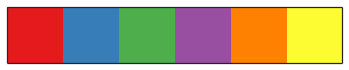

```python
seaborn = flotilla.visualize.seaborn # or import seaborn
mpl = flotilla.visualize.generic.mpl # or import matplotlib as mpl
palette = map(mpl.colors.rgb2hex, seaborn.color_palette('Set1'))
seaborn.palplot(palette)
```

### Assign colors for phenotypes.

```python
color_map = {'P': palette[1], # blue
             'N': palette[2], # green
             'M': palette[0], # red
             'S': palette[4]} # orange
```

### Create boolean columns for each phenotype, this will be useful later.

```python
for phenotype in ['P', 'N', 'M', 'S']:
    metadata[phenotype + '_cell'] = metadata['phenotype'] == phenotype
```

```python
study = flotilla.Study(#study metadata
                       sample_metadata=metadata,
                       #a version for this study, to track changes
                       version='0.1.0',
                       #pandas.DataFrame with expression data, created above
                       expression_data=expression_data,
                       #column in study.expression.feature_data to map ensg id to symbols
                       #(default feature_data is in flotilla_packages/<species>)
                       expression_feature_rename_col='gene_name',
                       #pandas.DataFrame with splicing data, created above
                       splicing_data=splicing_data,
                       #column in study.splicing.feature_data to map ensg id to symbols
                       #(default feature_data is in flotilla_packages/<species>)
                       splicing_feature_rename_col='gene_name',
                       #pandas.DataFrame with mapping statistics, created above
                       mapping_stats_data=mapstats_data,
                       #column with number of mapped reads
                       mapping_stats_number_mapped_col='Uniquely mapped reads number',
                       #specify species. So far we've built hg19/mm10
                       species='hg19',
                       #specify which column of metadata holds phenotype information
                       metadata_phenotype_col ='phenotype',
                       #specify a dictionary mapping phenotype to colors
                       metadata_phenotype_to_color=color_map,
                       #specify the order which you would like samples to be plotted:
                       metadata_phenotype_order=["P", "N", "M", "S"],
                       #specify a column that indicates whether a sample is pooled or single-cell
                       metadata_pooled_col='pooled_samples',
                       default_sample_subset='all_samples',
                       )
```

```
2014-10-31 00:18:09	Initializing Study
2014-10-31 00:18:09	Initializing Predictor configuration manager for Study
2014-10-31 00:18:09	Predictor ExtraTreesClassifier is of type <class 'sklearn.ensemble.forest.ExtraTreesClassifier'>
2014-10-31 00:18:09	Added ExtraTreesClassifier to default predictors
2014-10-31 00:18:09	Predictor ExtraTreesRegressor is of type <class 'sklearn.ensemble.forest.ExtraTreesRegressor'>
2014-10-31 00:18:09	Added ExtraTreesRegressor to default predictors
2014-10-31 00:18:09	Predictor GradientBoostingClassifier is of type <class 'sklearn.ensemble.gradient_boosting.GradientBoostingClassifier'>
2014-10-31 00:18:09	Added GradientBoostingClassifier to default predictors
2014-10-31 00:18:09	Predictor GradientBoostingRegressor is of type <class 'sklearn.ensemble.gradient_boosting.GradientBoostingRegressor'>
2014-10-31 00:18:09	Added GradientBoostingRegressor to default predictors
2014-10-31 00:18:09	Loading metadata
2014-10-31 00:18:09	Loading species metadata from ~/flotilla_packages
2014-10-31 00:18:31	Loading expression data
2014-10-31 00:18:31	Initializing expression
2014-10-31 00:18:31	Done initializing expression
2014-10-31 00:18:34	Loading splicing data
2014-10-31 00:18:34	Initializing splicing
2014-10-31 00:18:34	Done initializing splicing
2014-10-31 00:18:34	Successfully initialized a Study object!
```

```
No phenotype to marker (matplotlib plotting symbol) was provided, so each phenotype will be plotted as a circle in the PCA visualizations.
```

## Save data and metadata

### To be loaded in other notebooks for analysis.

```python
study.save('neural_diff_demo')
```

```
Wrote datapackage to /Users/lovci/flotilla_projects/neural_diff_demo/datapackage.json
```

## Summary

- Loaded data from multiple sources into a `flotilla.Study` object.
- The `Study` object contains mapping data, expression data, splicing data, sample metadata and feature (gene/splicing event) metadata.
- This ensures that data will be identical across multiple notebooks where analysis might be performed.
- This puts the data in one place, to be shared easily *(AWS?)*.

## Next steps

Now, continue to the Dimensionality Reduction notebook.